# Synthetic Insurance Analysis

Anshu Kumar & Sonu Kumar

2025-04-28

#Load Necessary Libraries

```r
library(tidyverse)
library(dplyr)
library(readr)
library(MASS)
```

```r
library(ggplot2)
library(GGally)
```

*Firstly we take important Libraries so we can perform our next task*

# 1. Data Understanding

# Load Dataset

```r
insurance_data = read_csv("C:/Users/LENOVO/Downloads/insurance.zip")
View(insurance_data)
```

*We started by loading the insurance dataset using read_csv() and viewed it with View() to familiarize ourselves with the data.*

#Look the structure & Summarization of dataset

```r
glimpse(insurance_data)
```

```
## Rows: 10,000
## Columns: 27
## $ Age                                <dbl> 47, 37, 49, 62, 36, 36, 63, 51, 32,…
## $ Is_Senior                          <dbl> 0, 0, 0, 1, 0, 0, 1, 0, 0, 0, 0, 0,…
## $ Marital_Status                     <chr> "Married", "Married", "Married", "M…
## $ Married_Premium_Discount           <dbl> 86, 86, 86, 86, 0, 86, 86, 0, 86, 0…
## $ Prior_Insurance                    <chr> "1-5 years", "1-5 years", "1-5 year…
## $ Prior_Insurance_Premium_Adjustment <dbl> 50, 50, 50, 0, 0, 0, 50, 100, 0, 0,…
## $ Claims_Frequency                   <dbl> 0, 0, 1, 1, 2, 0, 0, 0, 0, 1, 1, 1,…
## $ Claims_Severity                    <chr> "Low", "Low", "Low", "Low", "Low", …
## $ Claims_Adjustment                  <dbl> 0, 0, 50, 50, 100, 0, 0, 0, 0, 200,…
## $ Policy_Type                        <chr> "Full Coverage", "Full Coverage", "…
## $ Policy_Adjustment                  <dbl> 0, 0, 0, 0, 0, -200, 0, 0, -200, 0,…
## $ Premium_Amount                     <dbl> 2286, 2336, 2386, 2336, 2350, 1936,…
## $ Safe_Driver_Discount               <dbl> 0, 0, 0, 0, 0, 0, 1, 0, 0, 1, 0, 0,…
## $ Multi_Policy_Discount              <dbl> 0, 0, 0, 0, 0, 0, 0, 1, 1, 0, 1, 0,…
## $ Bundling_Discount                  <dbl> 0, 0, 0, 0, 0, 1, 0, 0, 0, 0, 0, 0,…
## $ Total_Discounts                    <dbl> 0, 0, 0, 0, 0, 50, 50, 50, 50, 50, …
## $ Source_of_Lead                     <chr> "Agent", "Online", "Online", "Onlin…
## $ Time_Since_First_Contact           <dbl> 10, 22, 28, 4, 14, 13, 2, 1, 16, 27…
## $ Conversion_Status                  <dbl> 0, 0, 0, 1, 1, 1, 1, 0, 1, 0, 1, 1,…
## $ Website_Visits                     <dbl> 5, 5, 4, 6, 8, 4, 5, 3, 5, 5, 3, 3,…
## $ Inquiries                          <dbl> 1, 1, 4, 2, 4, 1, 1, 0, 1, 3, 2, 1,…
## $ Quotes_Requested                   <dbl> 2, 2, 1, 2, 2, 1, 2, 2, 3, 2, 1, 3,…
## $ Time_to_Conversion                 <dbl> 99, 99, 99, 2, 10, 7, 1, 99, 3, 99,…
## $ Credit_Score                       <dbl> 704, 726, 772, 809, 662, 729, 795, …
## $ Premium_Adjustment_Credit          <dbl> -50, -50, -50, -50, 50, -50, -50, 5…
## $ Region                             <chr> "Suburban", "Urban", "Urban", "Urba…
## $ Premium_Adjustment_Region          <dbl> 50, 100, 100, 100, 50, 0, 100, 50, …
```

```r
summary(insurance_data)
```

```
##       Age          Is_Senior      Marital_Status     Married_Premium_Discount
##  Min.   :18.00   Min.   :0.0000   Length:10000       Min.   : 0.00
##  1st Qu.:29.00   1st Qu.:0.0000   Class :character   1st Qu.: 0.00
##  Median :39.00   Median :0.0000   Mode  :character   Median : 0.00
##  Mean   :39.99   Mean   :0.1593                      Mean   :42.13
##  3rd Qu.:50.00   3rd Qu.:0.0000                      3rd Qu.:86.00
##  Max.   :90.00   Max.   :1.0000                      Max.   :86.00
##  Prior_Insurance    Prior_Insurance_Premium_Adjustment Claims_Frequency
##  Length:10000       Min.   :  0.00                     Min.   :0.0000
##  Class :character   1st Qu.:  0.00                     1st Qu.:0.0000
##  Mode  :character   Median : 50.00                     Median :0.0000
##                     Mean   : 47.62                     Mean   :0.4972
##                     3rd Qu.: 50.00                     3rd Qu.:1.0000
##                     Max.   :100.00                     Max.   :5.0000
##  Claims_Severity    Claims_Adjustment Policy_Type        Policy_Adjustment
##  Length:10000       Min.   :  0.00    Length:10000       Min.   :-200.00
##  Class :character   1st Qu.:  0.00    Class :character   1st Qu.:-200.00
##  Mode  :character   Median :  0.00    Mode  :character   Median :   0.00
##                     Mean   : 36.78                       Mean   : -79.86
##                     3rd Qu.: 50.00                       3rd Qu.:   0.00
##                     Max.   :800.00                       Max.   :   0.00
##  Premium_Amount Safe_Driver_Discount Multi_Policy_Discount Bundling_Discount
##  Min.   :1800   Min.   :0.0000       Min.   :0.0000        Min.   :0.0000
##  1st Qu.:2100   1st Qu.:0.0000       1st Qu.:0.0000        1st Qu.:0.0000
##  Median :2236   Median :0.0000       Median :0.0000        Median :0.0000
##  Mean   :2220   Mean   :0.1999       Mean   :0.3051        Mean   :0.0972
##  3rd Qu.:2336   3rd Qu.:0.0000       3rd Qu.:1.0000        3rd Qu.:0.0000
##  Max.   :2936   Max.   :1.0000       Max.   :1.0000        Max.   :1.0000
##  Total_Discounts  Source_of_Lead     Time_Since_First_Contact Conversion_Status
##  Min.   :  0.00   Length:10000       Min.   : 1.00            Min.   :0.0000
##  1st Qu.:  0.00   Class :character   1st Qu.: 8.00            1st Qu.:0.0000
##  Median : 50.00   Mode  :character   Median :16.00            Median :1.0000
##  Mean   : 30.11                      Mean   :15.48            Mean   :0.5767
##  3rd Qu.: 50.00                      3rd Qu.:23.00            3rd Qu.:1.0000
##  Max.   :150.00                      Max.   :30.00            Max.   :1.0000
##  Website_Visits     Inquiries     Quotes_Requested Time_to_Conversion
##  Min.   : 0.000   Min.   :0.000   Min.   :1.000    Min.   : 1.00
##  1st Qu.: 3.000   1st Qu.:1.000   1st Qu.:1.000    1st Qu.: 6.00
##  Median : 5.000   Median :2.000   Median :2.000    Median :12.00
##  Mean   : 5.023   Mean   :1.997   Mean   :1.997    Mean   :46.07
##  3rd Qu.: 6.000   3rd Qu.:3.000   3rd Qu.:3.000    3rd Qu.:99.00
##  Max.   :16.000   Max.   :9.000   Max.   :3.000    Max.   :99.00
##   Credit_Score   Premium_Adjustment_Credit    Region
##  Min.   :530.0   Min.   :-50.00            Length:10000
##  1st Qu.:681.0   1st Qu.:-50.00            Class :character
##  Median :715.0   Median :-50.00            Mode  :character
##  Mean   :714.3   Mean   :-11.32
##  3rd Qu.:748.0   3rd Qu.: 50.00
##  Max.   :850.0   Max.   : 50.00
##  Premium_Adjustment_Region
##  Min.   :  0.00
##  1st Qu.: 50.00
##  Median : 50.00
##  Mean   : 64.33
##  3rd Qu.:100.00
##  Max.   :100.00
```

*We then used glimpse() to get a quick overview of the dataset’s structure and summary() to understand the statistical properties of each variable.*

# 2. Data Cleaning

# Check for Missing Values

```r
sum(is.na(insurance_data))
```

```
## [1] 0
```

*We checked for any missing values using sum(is.na()) and found whether our data was complete.*

#Remove Duplicate Records

```r
insurance_data = distinct(insurance_data)
distinct(insurance_data)
```

```
## # A tibble: 10,000 × 27
##      Age Is_Senior Marital_Status Married_Premium_Discount Prior_Insurance
##    <dbl>     <dbl> <chr>                             <dbl> <chr>
##  1    47         0 Married                              86 1-5 years
##  2    37         0 Married                              86 1-5 years
##  3    49         0 Married                              86 1-5 years
##  4    62         1 Married                              86 >5 years
##  5    36         0 Single                                0 >5 years
##  6    36         0 Married                              86 >5 years
##  7    63         1 Married                              86 1-5 years
##  8    51         0 Single                                0 <1 year
##  9    32         0 Married                              86 >5 years
## 10    48         0 Single                                0 >5 years
## # ℹ 9,990 more rows
## # ℹ 22 more variables: Prior_Insurance_Premium_Adjustment <dbl>,
## #   Claims_Frequency <dbl>, Claims_Severity <chr>, Claims_Adjustment <dbl>,
## #   Policy_Type <chr>, Policy_Adjustment <dbl>, Premium_Amount <dbl>,
## #   Safe_Driver_Discount <dbl>, Multi_Policy_Discount <dbl>,
## #   Bundling_Discount <dbl>, Total_Discounts <dbl>, Source_of_Lead <chr>,
## #   Time_Since_First_Contact <dbl>, Conversion_Status <dbl>, …
```

*We removed any duplicate records by applying distinct(), ensuring that our dataset only contains unique observations.*

# 3. Descriptive Analysis

# Average age of policyholders

```r
average_age = mean(insurance_data$Age)
print(paste("Average Age:", average_age))
```

```
## [1] "Average Age: 39.9917"
```

*We calculated the average age of the policyholders to understand the typical customer profile.*

#Proportion of senior citizens

```r
proportion_senior = mean(insurance_data$Is_Senior)
print(paste("Proportion of Senior Citizens:", proportion_senior))
```

```
## [1] "Proportion of Senior Citizens: 0.1593"
```

*We found the proportion of senior citizens by taking the mean of the Is_Senior column.*

#Distribution of marital status

```r
marital_status_dist = insurance_data %>%
  group_by(Marital_Status) %>%
  summarise(count = n())
print(marital_status_dist)
```

```
## # A tibble: 4 × 2
##   Marital_Status count
##   <chr>          <int>
## 1 Divorced         920
## 2 Married         4899
## 3 Single          3259
## 4 Widowed          922
```

*We examined the distribution of marital status by grouping and counting the number of policyholders in each category.*

#Average premium amount

```r
average_premium = mean(insurance_data$Premium_Amount)
print(paste("Average Premium Amount:", average_premium))
```

```
## [1] "Average Premium Amount: 2219.5714"
```

*We computed the average premium amount to get a sense of the typical insurance cost.*

#Average premium amount for each region

```r
average_premium_region = insurance_data %>%
  group_by(Region) %>%
  summarise(average_premium = mean(Premium_Amount))
print(average_premium_region)
```

```
## # A tibble: 3 × 2
##   Region   average_premium
##   <chr>              <dbl>
## 1 Rural              2157.
## 2 Suburban           2202.
## 3 Urban              2256.
```

*We analyzed the average premium amount across different regions to see if there were any geographical differences.*

#Distribution of claims frequency

```r
claims_frequency_dist = insurance_data %>%
  group_by(Claims_Frequency) %>%
  summarise(count = n())
print(claims_frequency_dist)
```

```
## # A tibble: 6 × 2
##   Claims_Frequency count
##              <dbl> <int>
## 1                0  6126
## 2                1  2965
## 3                2   745
## 4                3   141
## 5                4    21
## 6                5     2
```

*We explored the distribution of claims frequency by counting occurrences in category.*

#Distribution of claims severity

```r
claims_severity_dist = insurance_data %>%
  group_by(Claims_Severity) %>%
  summarise(count = n())
print(claims_severity_dist)
```

```
## # A tibble: 3 × 2
##   Claims_Severity count
##   <chr>           <int>
## 1 High              959
## 2 Low              7003
## 3 Medium           2038
```

*We explored the distribution of claims severity by counting occurrences in category.*

#Average age by marital status

```r
average_age_marital_status = insurance_data %>%
  group_by(Marital_Status) %>%
  summarise(average_age = mean(Age))
print(average_age_marital_status)
```

```
## # A tibble: 4 × 2
##   Marital_Status average_age
##   <chr>                <dbl>
## 1 Divorced              42.3
## 2 Married               39.8
## 3 Single                39.1
## 4 Widowed               41.8
```

*We calculated the average age by marital status to check if age varies between different marital statuses.*

#Most common claims severity

```r
common_claims_severity = insurance_data %>%
  group_by(Claims_Severity) %>%
  summarise(count = n()) %>%
  arrange(desc(count)) %>%
  slice(1)
print(common_claims_severity)
```

```
## # A tibble: 1 × 2
##   Claims_Severity count
##   <chr>           <int>
## 1 Low              7003
```

*We identified the most common claims severity level among the policyholders.*

# 4. Correlation and Relationship Analysis

#Correlation between Age and Premium Amount

```r
correlation_age_premium = cor(insurance_data$Age, insurance_data$Premium_Amount)
print(paste("Correlation between Age and Premium Amount:", correlation_age_premium))
```

```
## [1] "Correlation between Age and Premium Amount: -0.0295406633794125"
```

*We calculated the correlation between age and premium amount to understand if age impacts how much premium a person pays.*

#Correlation between Prior Insurance Premium Adjustment and Current Premium Amount

```r
correlation_prior_current_premium = cor(
  insurance_data$Prior_Insurance_Premium_Adjustment,
  insurance_data$Premium_Amount)
print(paste("Correlation between Prior Insurance Premium Adjustment and Current Premium Amount:", correlation_prior_current_premium))
```

```
## [1] "Correlation between Prior Insurance Premium Adjustment and Current Premium Amount: 0.234540830168632"
```

*We measured the correlation between prior insurance premium adjustments and current premium amounts to see if there was any relationship.*

#Effect of Prior Insurance on Claims Frequency and Severity

```r
prior_insurance_effect = insurance_data %>%
  group_by(Prior_Insurance) %>%
  summarise(
    average_claims_frequency = mean(Claims_Frequency),
    average_claims_severity = mean(as.numeric(Claims_Severity))
  )
print(prior_insurance_effect)
```

```
## # A tibble: 3 × 3
##   Prior_Insurance average_claims_frequency average_claims_severity
##   <chr>                              <dbl>                   <dbl>
## 1 1-5 years                          0.492                      NA
## 2 <1 year                            0.493                      NA
## 3 >5 years                           0.512                      NA
```

#Relationship between Policy Type and Premium Amount

```r
policy_type_premium = insurance_data %>%
  group_by(Policy_Type) %>%
  summarise(average_premium = mean(Premium_Amount))
print(policy_type_premium)
```

```
## # A tibble: 2 × 2
##   Policy_Type    average_premium
##   <chr>                    <dbl>
## 1 Full Coverage            2300.
## 2 Liability-Only           2099.
```

*We checked how the type of policy affects the average premium by grouping data by Policy_Type.*

#Categorizing Credit Score Ranges

```r
insurance_data = insurance_data %>%
  mutate(Credit_Score_Range = case_when(
    Credit_Score >= 750 ~ "Excellent (750+)",
    Credit_Score >= 700 & Credit_Score < 750 ~ "Good (700-749)",
    Credit_Score >= 650 & Credit_Score < 700 ~ "Fair (650-699)",
    Credit_Score < 650 ~ "Poor (<650)"
  ))
```

*We categorized credit scores into meaningful ranges (Excellent, Good, Fair, Poor) to better segment the customers.* *Its create One another Column in dataset*

#Average premium amount by Credit Score Range

```r
average_premium_credit_score = insurance_data %>%
  group_by(Credit_Score_Range) %>%
  summarise(average_premium = mean(Premium_Amount))
print(average_premium_credit_score)
```

```
## # A tibble: 4 × 2
##   Credit_Score_Range average_premium
##   <chr>                        <dbl>
## 1 Excellent (750+)             2184.
## 2 Fair (650-699)               2279.
## 3 Good (700-749)               2182.
## 4 Poor (<650)                  2284.
```

*We calculated the average premium amount for each credit score range to see if creditworthiness affects premiums.*

#Premium differences by Marital Status

```r
premium_marital_status = insurance_data %>%
  group_by(Marital_Status) %>%
  summarise(average_premium = mean(Premium_Amount))
print(premium_marital_status)
```

```
## # A tibble: 4 × 2
##   Marital_Status average_premium
##   <chr>                    <dbl>
## 1 Divorced                 2173.
## 2 Married                  2264.
## 3 Single                   2179.
## 4 Widowed                  2175.
```

*We compared premium differences across different marital statuses.*

#Claims Frequency differences by Policy Type

```r
claims_frequency_policy = insurance_data %>%
  group_by(Policy_Type) %>%
  summarise(average_claims_frequency = mean(Claims_Frequency))
print(claims_frequency_policy)
```

```
## # A tibble: 2 × 2
##   Policy_Type    average_claims_frequency
##   <chr>                             <dbl>
## 1 Full Coverage                     0.497
## 2 Liability-Only                    0.497
```

*We examined how claims frequency varies across different policy types.*

#Claims Adjustment by Policy Type

```r
claims_adjustment_policy = insurance_data %>%
  group_by(Policy_Type) %>%
  summarise(average_claims_adjustment = mean(Claims_Adjustment))
print(claims_adjustment_policy)
```

```
## # A tibble: 2 × 2
##   Policy_Type    average_claims_adjustment
##   <chr>                              <dbl>
## 1 Full Coverage                       36.4
## 2 Liability-Only                      37.3
```

*We studied how claims adjustment differs between various policy types.*

#Effect of Prior Insurance Premium Adjustment on Current Premium Amount

```r
effect_prior_insurance = insurance_data %>%
  group_by(Prior_Insurance_Premium_Adjustment) %>%
  summarise(average_current_premium = mean(Premium_Amount))
print(effect_prior_insurance)
```

```
## # A tibble: 3 × 2
##   Prior_Insurance_Premium_Adjustment average_current_premium
##                                <dbl>                   <dbl>
## 1                                  0                   2174.
## 2                                 50                   2220.
## 3                                100                   2276.
```

#Effect of Claims Adjustment on Premium Amount

```r
effect_claims_adjustment = insurance_data %>%
  group_by(Claims_Adjustment) %>%
  summarise(average_premium_amount = mean(Premium_Amount))
print(effect_claims_adjustment)
```

```
## # A tibble: 10 × 2
##    Claims_Adjustment average_premium_amount
##                <dbl>                  <dbl>
##  1                 0                  2183.
##  2                50                  2229.
##  3               100                  2289.
##  4               150                  2334.
##  5               200                  2379.
##  6               250                  2443
##  7               300                  2484.
##  8               400                  2560.
##  9               600                  2802.
## 10               800                  2900
```

*We also explored how claims adjustment levels are related to premium amounts.*

# 5. Data Regression

#Predict Premium Amount based on Age and Credit Score

```r
Predict_Premium_Amount = lm(Premium_Amount ~ Age + Credit_Score, data = insurance_data)
summary(Predict_Premium_Amount)
```

```
##
## Call:
## lm(formula = Premium_Amount ~ Age + Credit_Score, data = insurance_data)
##
## Residuals:
##     Min      1Q  Median      3Q     Max
## -426.41 -105.61    8.95  102.44  758.00
##
## Coefficients:
##                Estimate Std. Error t value Pr(>|t|)
## (Intercept)  2767.44236   21.07567 131.310   <2e-16 ***
## Age            -0.30694    0.10229  -3.001   0.0027 **
## Credit_Score   -0.74987    0.02889 -25.958   <2e-16 ***
## ---
## Signif. codes:  0 '***' 0.001 '**' 0.01 '*' 0.05 '.' 0.1 ' ' 1
##
## Residual standard error: 143.7 on 9997 degrees of freedom
## Multiple R-squared:  0.06396,    Adjusted R-squared:  0.06378
## F-statistic: 341.6 on 2 and 9997 DF,  p-value: < 2.2e-16
```

*We built a linear regression model to predict premium amount based on age and credit score.This helped us understand the impact of these factors on the premium.* *summary() tells you how well the model fits, coefficients, R-squared, etc.*

#Predict Claims Frequency based on Age, Credit Score, and Prior Insurance

```r
Predict_Claims_Frequency = lm(Claims_Frequency ~ Age + Credit_Score + Prior_Insurance, data = insurance_data)
summary(Predict_Claims_Frequency)
```

```
##
## Call:
## lm(formula = Claims_Frequency ~ Age + Credit_Score + Prior_Insurance,
##     data = insurance_data)
##
## Residuals:
##     Min      1Q  Median      3Q     Max
## -0.5240 -0.4973 -0.4882  0.5041  4.5204
##
## Coefficients:
##                            Estimate Std. Error t value Pr(>|t|)
## (Intercept)               4.855e-01  1.059e-01   4.586 4.57e-06 ***
## Age                      -3.698e-04  5.137e-04  -0.720    0.472
## Credit_Score              3.103e-05  1.440e-04   0.216    0.829
## Prior_Insurance>5 years   1.991e-02  2.103e-02   0.947    0.344
## Prior_Insurance1-5 years -1.628e-03  1.839e-02  -0.089    0.929
## ---
## Signif. codes:  0 '***' 0.001 '**' 0.01 '*' 0.05 '.' 0.1 ' ' 1
##
## Residual standard error: 0.7162 on 9995 degrees of freedom
## Multiple R-squared:  0.000202,   Adjusted R-squared:  -0.0001981
## F-statistic: 0.5049 on 4 and 9995 DF,  p-value: 0.7322
```

*We developed another linear regression model to predict claims frequency using age, credit score, and prior insurance status.* *This model allowed us to study the factors affecting how often customers make claims.*

# 6. ANOVA Test

#Premium Amount difference across Marital Status

```r
Premium_Amount_Across_Marital_Status = aov(Premium_Amount ~ Marital_Status, data = insurance_data)
summary(Premium_Amount_Across_Marital_Status)
```

```
##                  Df    Sum Sq Mean Sq F value Pr(>F)
## Marital_Status    3  18779068 6259689   310.1 <2e-16 ***
## Residuals      9996 201784139   20186
## ---
## Signif. codes:  0 '***' 0.001 '**' 0.01 '*' 0.05 '.' 0.1 ' ' 1
```

*We performed a one-way ANOVA to determine whether the average Premium Amount differs significantly across different Marital Status groups (Single, Married, Divorced, etc.).*

*Null Hypothesis (H₀): There is no difference in Premium Amount between marital status groups.* *Alternative Hypothesis (H₁): At least one group has a different mean Premium Amount* *If the p-value is less than 0.05, we reject the null hypothesis, meaning that marital status does impact the Premium Amount.* *Conclusion Example:* *If p-value = 0.002 → “There is a significant difference in Premium Amount between marital status groups.”*

#Claims Frequency difference across Policy Type

```r
Claims_Frequency_across_Policy_Type = aov(Claims_Frequency ~ Policy_Type, data = insurance_data)
summary(Claims_Frequency_across_Policy_Type)
```

```
##               Df Sum Sq Mean Sq F value Pr(>F)
## Policy_Type    1      0  0.0000       0  0.993
## Residuals   9998   5128  0.5129
```

*We conducted a one-way ANOVA to check if the Claims Frequency significantly varies across different Policy Types.* *Null Hypothesis (H₀): The mean Claims Frequency is the same for all Policy Types.* *Alternative Hypothesis (H₁): At least one Policy Type has a different mean Claims Frequency.* *If the p-value is less than 0.05, we conclude that Policy Type affects how frequently claims are made.* *Conclusion Example:* *If p-value = 0.01 → “There is a significant difference in Claims Frequency between Policy Types, indicating that certain policy types are riskier.”*

#Premium Amount difference across Regions

```r
Premium_Amount_difference_across_Regions = aov(Premium_Amount ~ Region, data = insurance_data)
summary(Premium_Amount_difference_across_Regions)
```

```
##               Df    Sum Sq Mean Sq F value Pr(>F)
## Region         2  15632513 7816257   381.3 <2e-16 ***
## Residuals   9997 204930694   20499
## ---
## Signif. codes:  0 '***' 0.001 '**' 0.01 '*' 0.05 '.' 0.1 ' ' 1
```

*We performed a one-way ANOVA to investigate whether the Premium Amount significantly differs across different Regions.* *Null Hypothesis (H₀): The mean Premium Amount is the same across all regions.* *Alternative Hypothesis (H₁): At least one region has a different mean Premium Amount.* *A p-value less than 0.05 would suggest that the Premium Amount varies significantly by Region.* *Conclusion Example:* *If p-value = 0.04 → “Premiums differ significantly across regions, suggesting that geographic factors influence pricing.”*

# 7. Data Visualization

#Website Visits vs Premium Amount

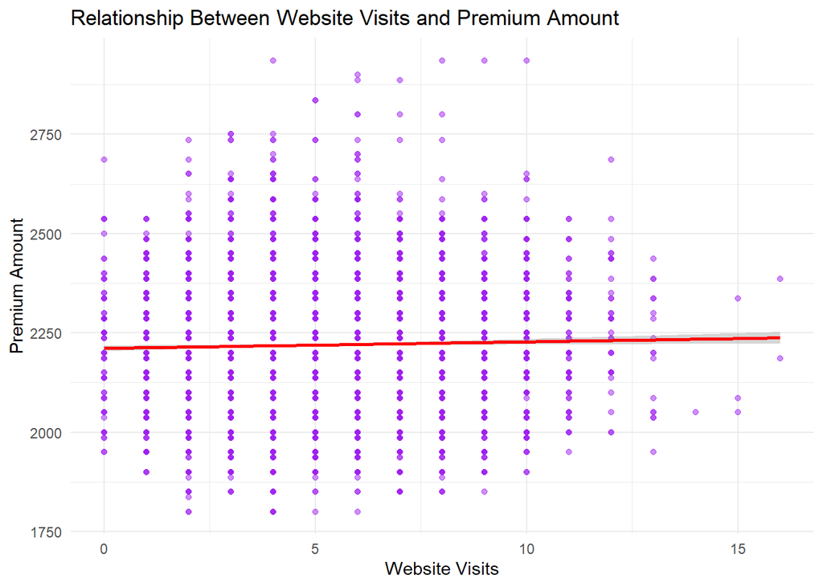

```r
ggplot(insurance_data, aes(x = Website_Visits, y = Premium_Amount)) +
  geom_point(alpha = 0.5, color = "purple") +
  geom_smooth(method = "lm", color = "red", se = TRUE) +
  labs(title = "Relationship Between Website Visits and Premium Amount",
       x = "Website Visits", y = "Premium Amount") +
  theme_minimal()
```

*We visualized the relationship between website visits and premium amount using a scatter plot with a linear trend line.*

#Boxplot of Age by Marital Status

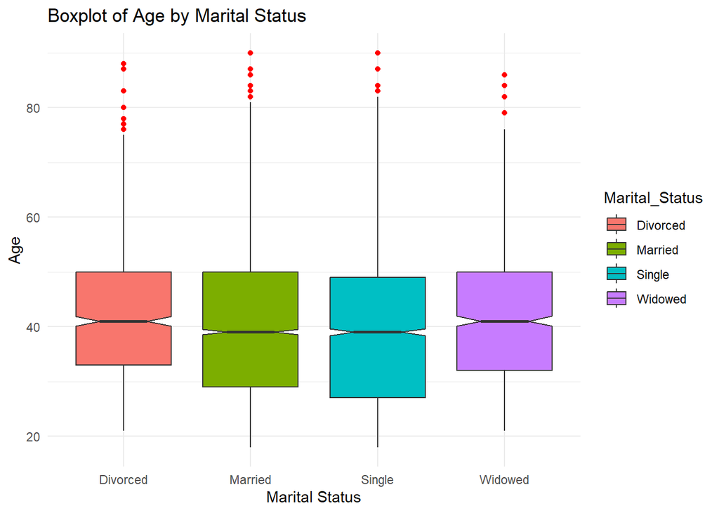

```r
ggplot(insurance_data, aes(x = Marital_Status, y = Age, fill = Marital_Status)) +
  geom_boxplot(outlier.color = "red", notch = TRUE) +
  labs(title = "Boxplot of Age by Marital Status", x = "Marital Status", y = "Age") +
  theme_minimal()
```

*We created a boxplot to compare the age distributions across different marital statuses.*

#Histogram of Credit Score

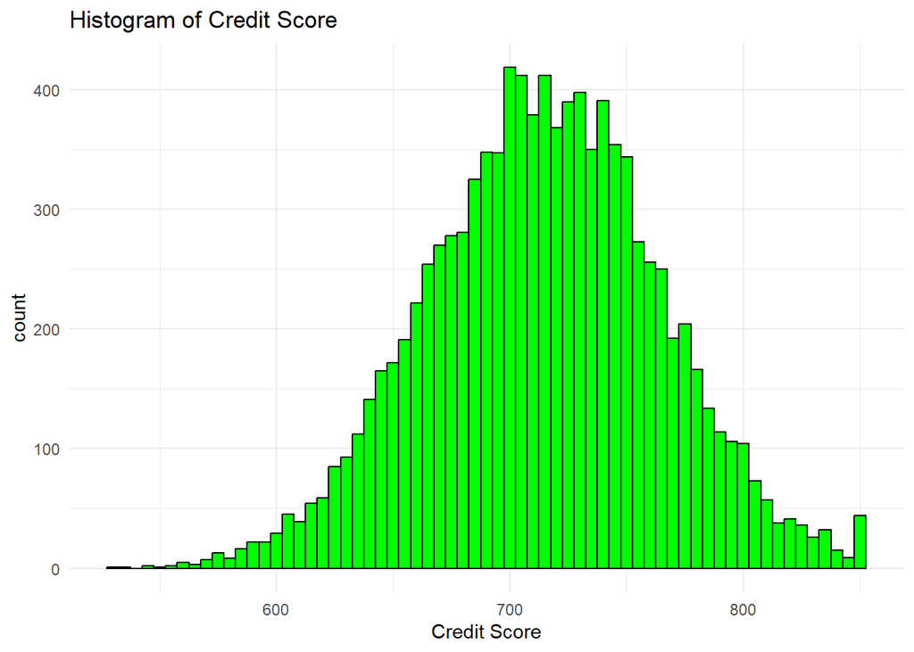

```r
ggplot(insurance_data, aes(x = Credit_Score)) +
  geom_histogram(binwidth = 5, fill = "green", color = "black") +
  labs(title = "Histogram of Credit Score", x = "Credit Score") +
  theme_minimal()
```

*We plotted a histogram to explore the distribution of credit scores among policyholders.*

#Customer Distribution across Regions

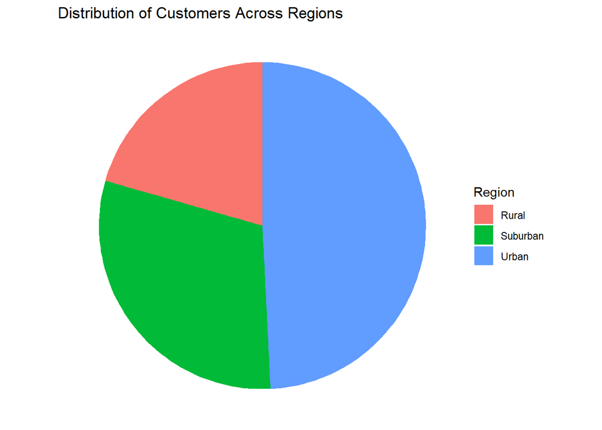

```r
insurance_data %>%
  group_by(Region) %>%
  summarise(Count = n()) %>%
  ggplot(aes(x = "", y = Count, fill = Region)) +
  geom_col(width = 1) +
  coord_polar(theta = "y") +
  labs(title = "Distribution of Customers Across Regions") +
  theme_void()
```

*We displayed the customer distribution across different regions using a pie chart to understand regional variations.*

#Claims Severity Distribution

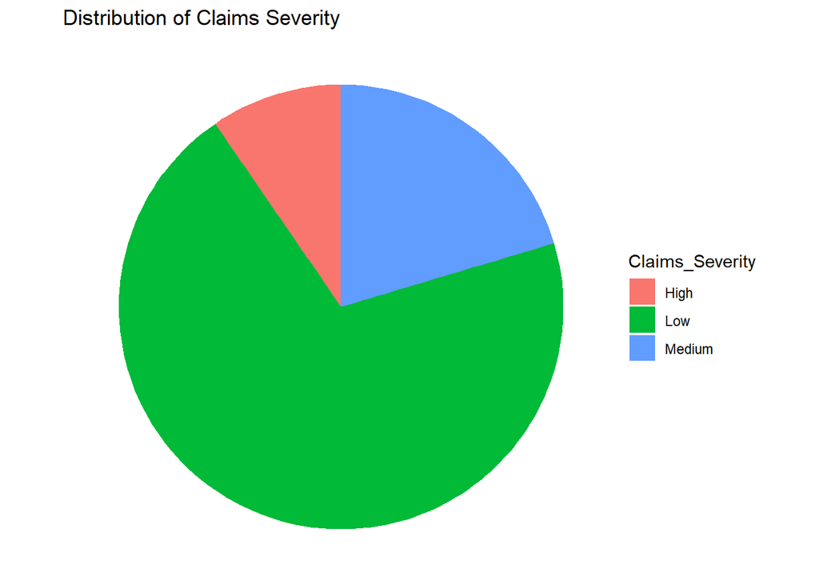

```r
insurance_data %>%
  group_by(Claims_Severity) %>%
  summarise(Count = n()) %>%
  ggplot(aes(x = "", y = Count, fill = Claims_Severity)) +
  geom_col(width = 1) +
  coord_polar(theta = "y") +
  labs(title = "Distribution of Claims Severity") +
  theme_void()
```

*We visualized the distribution of claims severity levels using both a pie chart and a bar chart.*

#Premium Amount by Credit Score Range

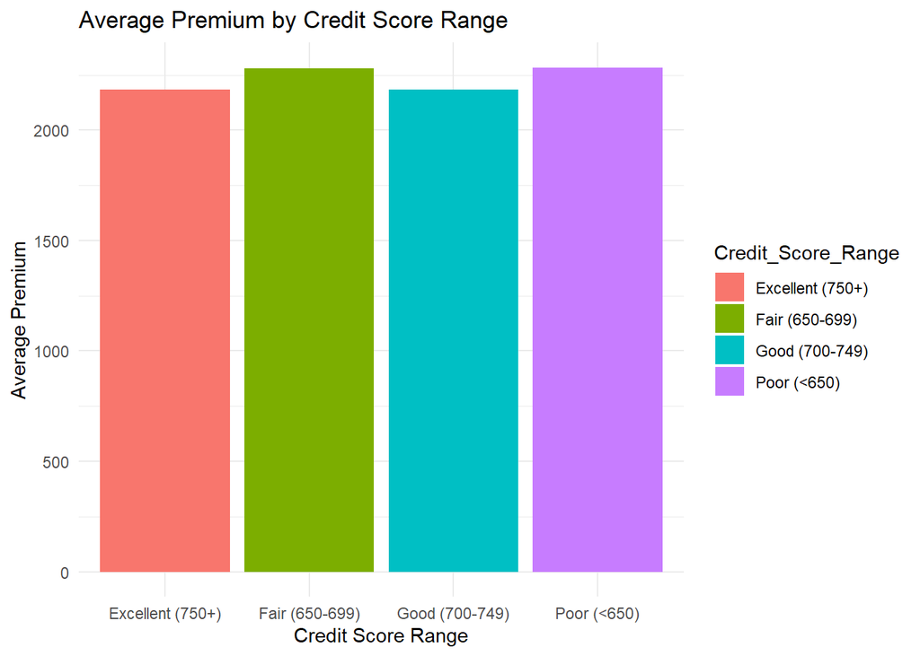

```r
insurance_data %>%
  group_by(Credit_Score_Range) %>%
  summarise(Average_Premium = mean(Premium_Amount, na.rm = TRUE)) %>%
  ggplot(aes(x = Credit_Score_Range, y = Average_Premium, fill = Credit_Score_Range)) +
  geom_col() +
  labs(title = "Average Premium by Credit Score Range", x = "Credit Score Range", y = "Average Premium") +
  theme_minimal()
```

*We showed how average premium amounts vary across different credit score ranges with a bar chart.*

#Senior vs Non-Senior Citizens Distribution

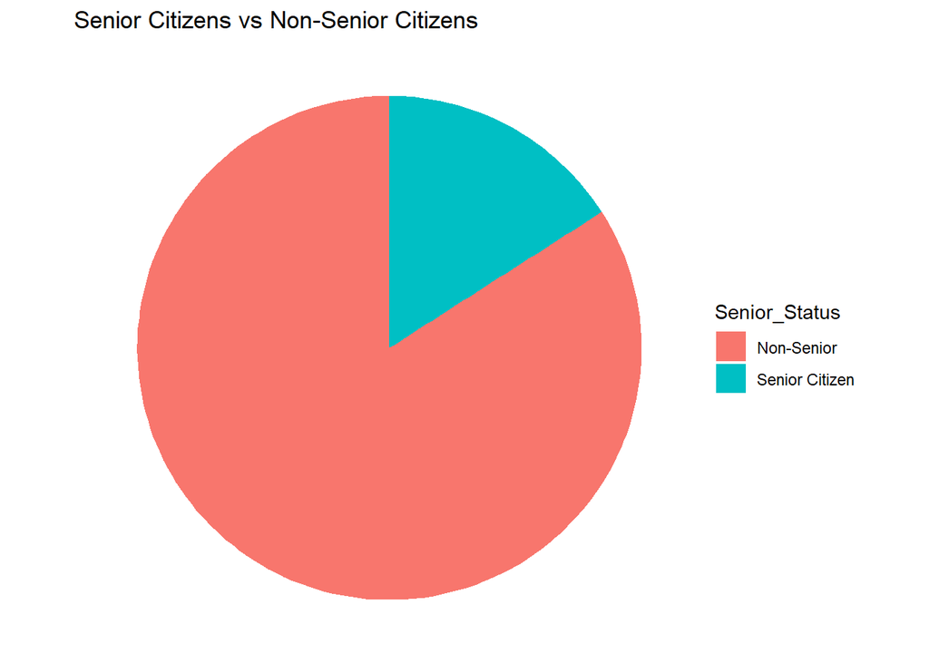

```r
insurance_data %>%
  mutate(Senior_Status = ifelse(Is_Senior == 1, "Senior Citizen", "Non-Senior")) %>%
  group_by(Senior_Status) %>%
  summarise(Count = n()) %>%
  ggplot(aes(x = "", y = Count, fill = Senior_Status)) +
  geom_col(width = 1) +
  coord_polar(theta = "y") +
  labs(title = "Senior Citizens vs Non-Senior Citizens") +
  theme_void()
```

*We compared the number of senior and non-senior citizens using a pie chart to understand the senior citizen customer base.*

#Claims Severity Distribution

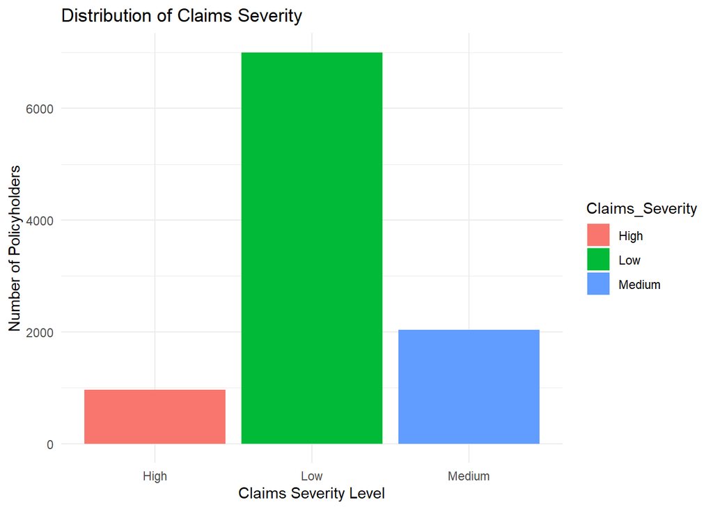

```r
insurance_data %>%
  group_by(Claims_Severity) %>%
  summarise(Count = n()) %>%
  ggplot(aes(x = Claims_Severity, y = Count, fill = Claims_Severity)) +
  geom_col() +
  labs(title = "Distribution of Claims Severity", x = "Claims Severity Level", y = "Number of Policyholders") +
  theme_minimal()
```

*We visualized claims severity distribution again through a bar chart for a different perspective.*

#How does the Average Premium Amount change with increasing Age?

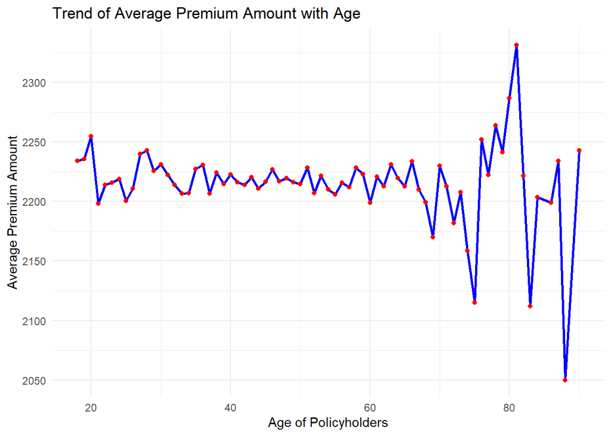

```r
age_premium_trend <- insurance_data %>%
  group_by(Age) %>%
  summarise(Average_Premium = mean(Premium_Amount, na.rm = TRUE))

ggplot(age_premium_trend, aes(x = Age, y = Average_Premium)) +
  geom_line(color = "blue", size = 1) +
  geom_point(color = "red", size = 1.5) +
  labs(title = "Trend of Average Premium Amount with Age",
       x = "Age of Policyholders",
       y = "Average Premium Amount") +
  theme_minimal()
```

*The line chart shows how the average premium amount changes as the age of policyholders increases.* *A rising trend would suggest that older customers generally pay higher premiums, possibly due to increased insurance risks.* *Any dips might suggest discounts or different premium structures for certain age groups.*

#Pairplot of Selected Features

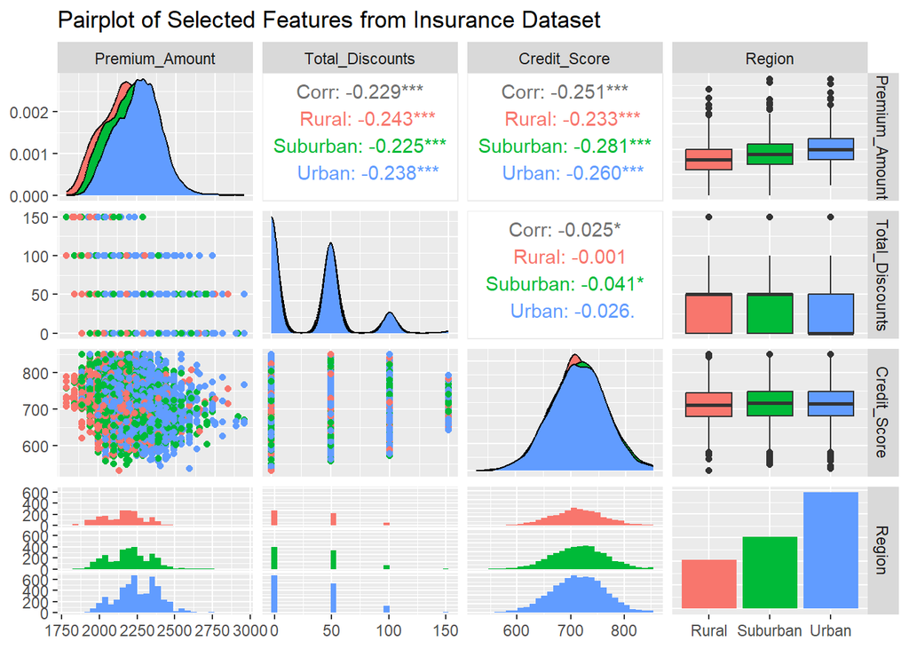

```r
insurance_subset <- insurance_data[, c("Premium_Amount", "Total_Discounts", "Credit_Score", "Region")]
ggpairs(insurance_subset,
        columns = 1:4,
        aes(color = Region),
        title = "Pairplot of Selected Features from Insurance Dataset")
```

*Finally, we created a pairplot of selected features — Premium Amount, Total Discounts, Credit Score, and Region — to study the relationships between these important variables.*